# R Notebook

## ddqc Tutorial

First, lets set up the workspace loading the ddqcR and Seurat packages

```r
library(Seurat)
library(ddqcR)
```

### Reading the data

For this tutorial we will use 10x mouse heart dataset provided by tabula muris  
https://s3.console.aws.amazon.com/s3/buckets/czb-tabula-muris-senis?region=us-west-2&prefix=10x/3_month/10X_P4_7/

First we need to unzip the data

```bash
tar -C data/ -xzf data/Heart_and_Aorta-10X_P7_4.gz
```

We will first load the data using the following commands.  
We recommend setting min.cells parameter of ‘CreateSeuratObject’ to 3

```r
data.mtx <- Read10X(data.dir = "data/Heart_and_Aorta-10X_P7_4/")
data <- CreateSeuratObject(counts = data.mtx, project = "pbmc3k", min.cells = 3)
data
```

```
An object of class Seurat
20103 features across 737280 samples within 1 assay
Active assay: RNA (20103 features, 0 variable features)
```

### Biology-centered data-driven quality control (ddqc)

ddqcR does adaptive quality control by clustering cells and picking a separate threshold for each cluster. It is described down below:

- Initial Qualtity Control (QC) is performed, when obvious low-quality cells are removed. By default those are cells with n_genes < 100 and percent_mito > 80.
- The cells are clustered with the clustering resolution 1.3 (default)
- Then thesholds are picked for each cluster. By default the following metrics are considered:
  - **Number of counts/UMIs**: keep cells that have n_counts greater than median - 2 Median Absolute Deviations (MAD)
  - **Number of genes**: keep cells that have n_genes greater than median - 2 MADs
  - **Percent of mitochondrial transctipts**: keep cells that have percent_mito less than median + 2 MADs
- In order to prevent the removal of healthy cells in clusters with high median n_genes and low percent_mito there are additional bounds for those thresholds:
  - Cluster-level threshold for n_genes can’t be greater than 200 (default). If it is greater, it will be set to 200.
  - Cluster-level threshold for percent_mito can’t be lower than 10 (default). If it is lower, it will be set to 10

To perform ddqc on a dataset, we first need to run `initialQC` function to remove obvious bad quality cells

```r
data <- initialQC(data)
```

Then we need to run `ddqc.metrics`  
This function will not filter the Seurat object itself, but will return a data.frame with filtering statistics

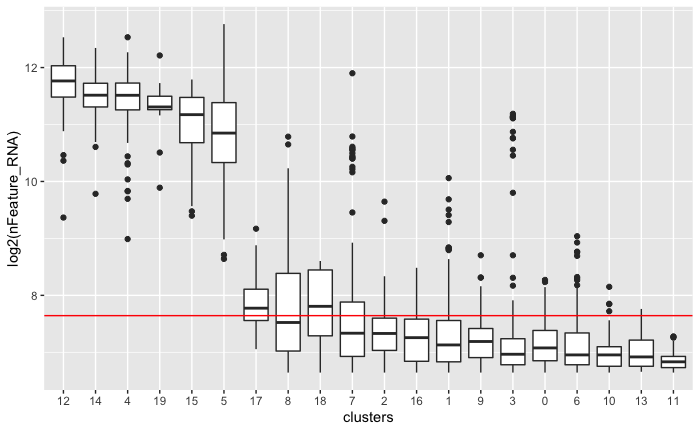

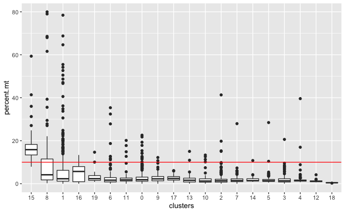

```r
df.qc <- ddqc.metrics(data)
```

### Outputs

There are two boxplots provided for exploratory data analysis:

- log2(n_genes) by cluster: shows log2 of number of genes for each cluster in the initial clustering. Red line at 200 genes (7.64 in log2 scale) represents the most common fixed threshold cutoff for n_genes.
- percent_mito by cluster: shows percent_mito for each cluster in the initial clustering. Red line at 10% represents the most common fixed threshold cutoff for percent_mito.

The function will return a dataframe containing the following info for each cell:

- `metric`: QC metric number
- `cluster_labels`: cluster from initial clustering performed by ddqc
- `metric.lower.co` and `metric.upper.co`: lower and upper cuttofs for each metric on which ddqc was performed. If ddqc was not performed for upper or lower end of this metric this field will be `None`
- `metric.passed.qc`: whether the cell passed qc for a given metric This information is useful if you want to understand based on which metric the cell was filtered out.

```r
df.qc
```

|  | cluster_labels | nCount_RNA | nCount_RNA.upper.co | nCount_RNA.lower.co | nCount_RNA.passed.qc | nFeature_RNA | nFeature_RNA.upper.co | nFeature_RNA.lower.co | nFeature_RNA.passed.qc | percent.mt | percent.mt.upper.co | percent.mt.lower.co | percent.mt.passed.qc | passed.qc |
| --- | --- | --- | --- | --- | --- | --- | --- | --- | --- | --- | --- | --- | --- | --- |
| AAACCTGAGAGTCTGG-1 | 3 | 146 | NaN | 76.8004 | TRUE | 133 | NaN | 68.6612 | TRUE | 1.3698630 | 10.00000 | NaN | TRUE | TRUE |
| AAACCTGAGCCAGTAG-1 | 2 | 171 | NaN | 62.6008 | TRUE | 143 | NaN | 66.1136 | TRUE | 0.5847953 | 10.00000 | NaN | TRUE | TRUE |
| AAACCTGCACGACGAA-1 | 5 | 5164 | NaN | -1687.0028 | TRUE | 2342 | NaN | -230.6400 | TRUE | 0.9101472 | 10.00000 | NaN | TRUE | TRUE |
| AAACCTGGTGAGTGAC-1 | 3 | 198 | NaN | 76.8004 | TRUE | 151 | NaN | 68.6612 | TRUE | 1.0101010 | 10.00000 | NaN | TRUE | TRUE |
| AAACCTGGTTACGCGC-1 | 9 | 148 | NaN | 63.3224 | TRUE | 125 | NaN | 68.9048 | TRUE | 5.4054054 | 10.00000 | NaN | TRUE | TRUE |
| AAACCTGGTTCCACGG-1 | 4 | 4886 | NaN | 2341.4476 | TRUE | 2360 | NaN | 200.0000 | TRUE | 2.1080639 | 10.00000 | NaN | TRUE | TRUE |
| AAACCTGTCTAACCGA-1 | 0 | 128 | NaN | 66.1136 | TRUE | 104 | NaN | 66.8004 | TRUE | 1.5625000 | 10.00000 | NaN | TRUE | TRUE |
| AAACCTGTCTCGATGA-1 | 5 | 4381 | NaN | -1687.0028 | TRUE | 2344 | NaN | -230.6400 | TRUE | 1.4608537 | 10.00000 | NaN | TRUE | TRUE |
| AAACGGGAGCGCTCCA-1 | 7 | 4550 | NaN | -4.4422 | TRUE | 1770 | NaN | 17.6878 | TRUE | 0.6813187 | 10.00000 | NaN | TRUE | TRUE |
| AAACGGGAGGATATAC-1 | 7 | 354 | NaN | -4.4422 | TRUE | 220 | NaN | 17.6878 | TRUE | 2.8248588 | 10.00000 | NaN | TRUE | TRUE |

[output cut: 990 more lines]

### Filter out the cells

Now, we will filter out the cells that failed ddqc. Here, we started with 2720 cells and retain 2579 cells.

```r
data <- filterData(data, df.qc)
data
```

```
An object of class Seurat
20103 features across 2579 samples within 1 assay
Active assay: RNA (20103 features, 0 variable features)
```

### Save the dataset

We will save the dataset as data.rds, which can then be imported into the scRNAseq pipeline of your choice for downstream analysis.

```r
saveRDS(data, file = "data.rds")
```